## **Dusky hopping mouse**

### Blamed on foxes

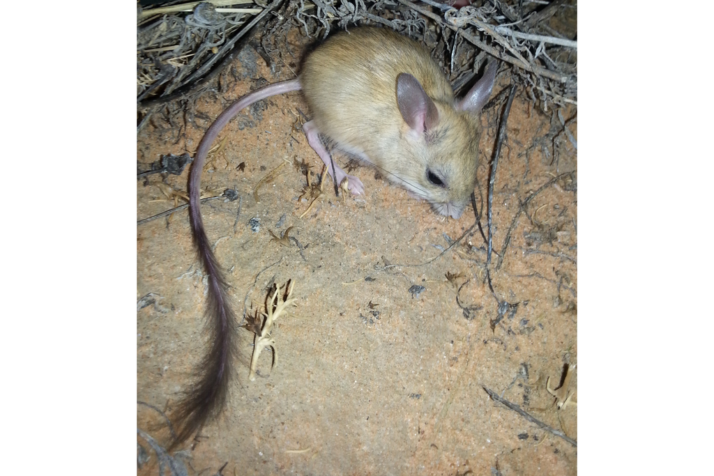

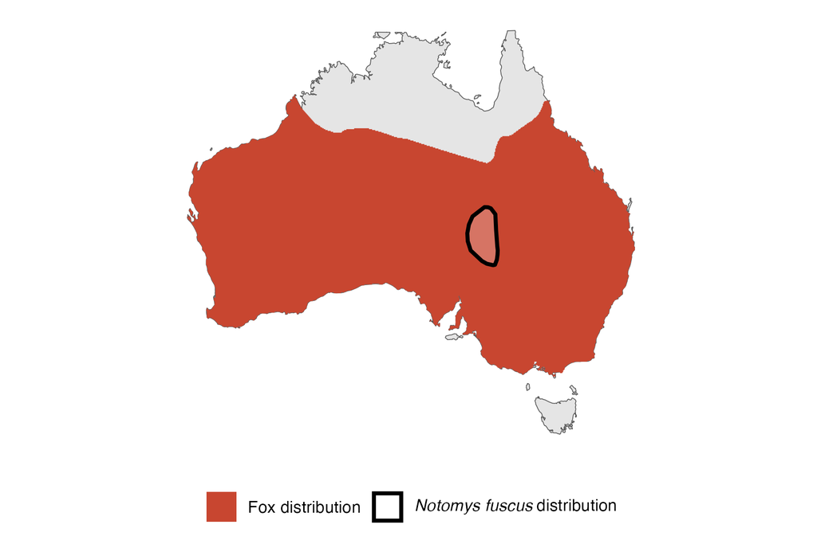

IUCN status: **Vulnerable**

EPBC Predator Threat Rating: **Not assessed**

IUCN claim: *“Predation by feral Domestic Cats (Felis catus; moderate to severe, across the entire range) and Red Foxes (Vulpes vulpes) represent another major threat”*

### Studies in support

Gordon et al. (2015) and Pedler et al. (2016) found negative correlations betwen fox abundance and hopping mouse abundance. Similarly, Letnic et al. (2009) found that negative correlation with fox abundance was the third most important predictor variable in a model (after positive correlation with dingoes and rain). Letnic & Koch (2010) reported higher fox abundance and lower hopping mouse abundance outside compared to inside the dingo barrier fence, but direct association not shown. Hopping mice have also been identified in the foxes’ diet (Feit et al. 2019), and more often than in the dingo’s diet (Letnic & Dworjanyn 2011).

### Studies not in support

Hopping mice were last confirmed at Charlotte Waters, NT, 20-15 years before foxes arrived, and in the Western Division of NSW 11 years before, to 14 years after, foxes arrived (Wallach and Lundgren 2025).

### Is the threat claim evidence-based?

Foxes have been documented among a range of ecological variables negatively correlated with dusky hopping mouse abundance in four studies. Causality for decline is uncertain due to potential confounding variables. In one region extirpation records pre-date the fox arrival record, and for the other it cannot be verified that extirpation occured after foxes arrived.

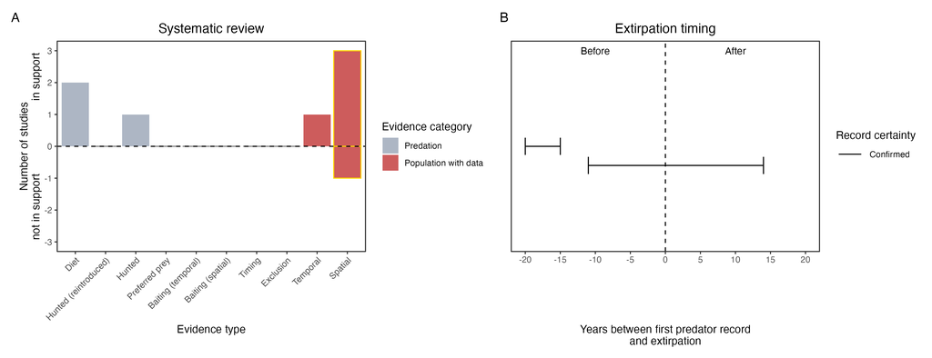

**Evidence linking *Notomys fuscus* to foxes.** **A.** Systematic review of evidence for an association between *Notomys fuscus* and foxes. Positive studies are in support of the hypothesis that foxes contribute to the decline of *Notomys fuscus*, negative studies are not in support. Predation studies include studies documenting hunting or scavenging; baiting studies are associations between poison baiting and threatened mammal abundance where information on predator abundance is not provided; population studies are associations between threatened mammal and predator abundance. Gold borders indicate studies that meet qualities of scientific rigour. **B.** Last records of extirpated populations relative to earliest local records of foxes. Error bars show minimum and maximum extinction intervals. Predator arrival records were digitized from Fairfax 2019. See methods section in Wallach and Lundgren 2025 for details on evidence categories.

### References

Fairfax, Dispersal of the introduced red fox (Vulpes vulpes) across Australia. Biol. Invasions 21, 1259-1268 (2019).

Feit, B., Feit, A. and Letnic, M., 2019. Apex predators decouple population dynamics between mesopredators and their prey. Ecosystems, 22, pp.1606-1617.

Gordon, C.E., Feit, A., Grüber, J. and Letnic, M., 2015. Mesopredator suppression by an apex predator alleviates the risk of predation perceived by small prey. Proceedings of the Royal Society B: Biological Sciences, 282(1802), p.20142870.

IUCN Red List. https://www.iucnredlist.org/ Accessed June 2023

Letnic, M. and Dworjanyn, S.A., 2011. Does a top predator reduce the predatory impact of an invasive mesopredator on an endangered rodent?. Ecography, 34(5), pp.827-835.

Letnic, M. and Koch, F., 2010. Are dingoes a trophic regulator in arid Australia? A comparison of mammal communities on either side of the dingo fence. Austral Ecology, 35(2), pp.167-175.

Letnic, M., Crowther, M.S. and Koch, F., 2009. Does a top‐predator provide an endangered rodent with refuge from an invasive mesopredator?. Animal Conservation, 12(4), pp.302-312.

Pedler, R.D., Brandle, R., Read, J.L., Southgate, R., Bird, P. and Moseby, K.E., 2016. Rabbit biocontrol and landscape‐scale recovery of threatened desert mammals. Conservation Biology, 30(4), pp.774-782.

Wallach A.D., Lundgren E.J. (2025) Review of evidence that foxes and cats cause extinctions of Australia’s endemic mammals. BioScience. DOI: 10.1093/biosci/biaf046